# 06-caribou-migration

### Barren-Ground Caribou Migration and Habitat

Caribou (Rangifer Tarandus), also known as Reindeer, is a terrestrial species whose habitat includes arctic tundra, boreal forests, and mountains of Eurasia and North America - spanning the arctic globally (COSEWIC, 2016; National Park Service, 2026; Rigell, n.d.). They are thought to have migrated from Eurasia eastward to Alaska and North America through Bering Land Bridge some hundreds of thousands of years ago (Joly et al., 2018). While not all caribous are migratory, its migratory subspecies cover the longest migratory distance per year among all land animals (Joly et al., 2018).

The most well-known of these migratory subspecies, especially in North America, is barren-ground caribou (Rangifer tarandus groenlandicus), whose habitat includes Canada, Alaska, and Greenland (COSEWIC, 2016; Joly et al., 2018). It should be noted that most, not all, herds of barren-ground caribou are migratory, and the migratory herds take their name from their calving grounds (also known as ‘natal grounds’)– for instance Porcupine caribou takes its name from the Porcupine River, stretching from Yukon territory in Canada to Alaska (Joly et al., 2018; Rigell, n.d.).*

[figure not shown]

Barren-ground caribou, Bauer, Erwin and Peggy, Public Domain, https://www.fws.gov/media/barren-ground-caribou

#### Migration

The main reason for barren-ground caribou migration is calving, which primarily happens in late Spring (late May - early June) (National Park Service, 2026; Rigell, n.d.). These caribous migrate, aggregate, and calve synchronously to reduce exposure to predation (Joly et al., 2018; Rigell, n.d.). Another related reason for their migration is seeking “nutritious forage high protein”, especially after calving (Joly et al., 2018, para. 4). To compensate for lack of nutrition in the winter, acquire body mass, and produce milk, caribou spend spring and summer to fulfill their dietary needs (Rigell, n.d.).

Barren-ground caribous start their northwards migration towards the Arctic coast, their calving grounds as early as late March (COSEWIC, 2016). In addition to the search for food, this northwards migration is partly driven by the appearance and harassment of mosquitoes and other insects in the summer months (Joly et al., 2018). With the onset of fall, caribou migrate southwards in search for forage in the winter (Joly et al., 2018). To preserve energy, caribous minimize their movement during the winter (Joly et al., 2018).

Among the barren-ground caribou, Porcupine caribou have the longest yearly migration route, placing them above any other terrestrial mammal** (Berkeland, n.d.). This caribou herd spends winter across the mountains and foothills of Brooks Range in western Alaska and central Yukon, travelling northwards in late March in order to give birth in their calving grounds in the coastal plains of northeast Alaska and northwest Canada in the month of May (Berkeland, n.d.; Rigell, n.d.).

Caribou holds an important role in the culture of some of the native communities in North America (COSEWIC, 2016; Joly et al., 2018). For instance, for the Gwich’in, who live in eastern and central Alaska, caribou plays an important spiritual role, in addition to being a source of food, clothing, and material (Rigell, n.d.). Therefore, the impacts of climate and environmental change on the range and patterns of caribou migration have a secondary effect on these communities’ cultural practices.

#### Disruptions

Causing earlier and longer growing seasons in the Arctic, climate change has resulted in an increase in the duration of presence and range of insects (Berkeland, n.d.). The amplification and extension of the insect harassment have led to the caribou spending lesser time on foraging while traveling further for cooler and windier areas, with implications on their survival and reproduction (Berkeland, n.d.). Given that caribous play a significant role in shaping the ecology of the northern reaches of North America (National Park Service, 2026), changes to their movement and migration patterns will impact the broader ecology of the region.

It should be noted that development is also an important factor in disrupting caribou migration, as a result of roads and other transportation routes cutting across their migration routes (Boulanger et al., 2024), expansion of economic and extractive development into their habitats (Association on American Indian Affairs, 2002), and the side effects of human development on the vegetation range and quality (Joly et al., 2018).

#### Analysis Plan

Here, we would like to see if we can find any patterns in the migration and habitat of barren-ground caribou -- in light of the literature.

**Notes**

*It should be noted that sometimes Porcupine caribou are treated as separate from barren-ground caribou (Rigell, n.d.). However, our data treats Porcupine caribou as part of the barren-ground subspecies.

**In their study using GPS data, Joly et al. (2019) found that while caribou have the longest annual terrestrial migration among land animals, gray wolves move the longest distance over the course of a year.

```python
%store -r
```

```python
### import packages

### folder/file management
import os
import pathlib

### handle tabular data
import pandas as pd

### handle geospatial vector data
import geopandas as gpd

### libraries for dynamic mapping

### manage coordinate reference systems
import cartopy.crs as ccrs

### customize the dynamic plot
import panel as pn

### handle plots
import matplotlib.pyplot as plt

### handle legends
import matplotlib.patches as Patch
import matplotlib.lines as Line2D

### make dynamic plot with geodataframe
import hvplot.pandas
import holoviews as hv

### get month names
import calendar
```

#### Data

We are going to use two geodataframes in our analysis: ecoreg_gdf and gbif_gdf.

```python
ecoreg_gdf
```

|  | OBJECTID | ECO_NAME | BIOME_NUM | BIOME_NAME | REALM | ECO_BIOME_ | NNH | ECO_ID | SHAPE_LENG | SHAPE_AREA | NNH_NAME | COLOR | COLOR_BIO | COLOR_NNH | LICENSE | geometry |
| --- | --- | --- | --- | --- | --- | --- | --- | --- | --- | --- | --- | --- | --- | --- | --- | --- |
| 0 | 1.0 | Adelie Land tundra | 11.0 | Tundra | Antarctica | AN11 | 1 | 117 | 9.749780 | 0.038948 | Half Protected | #63CFAB | #9ED7C2 | #257339 | CC-BY 4.0 | POLYGON ((153.52302 -68.79056, 153.62005 -68.8... |
| 1 | 2.0 | Admiralty Islands lowland rain forests | 1.0 | Tropical & Subtropical Moist Broadleaf Forests | Australasia | AU01 | 2 | 135 | 4.800349 | 0.170599 | Nature Could Reach Half Protected | #70A800 | #38A700 | #7BC141 | CC-BY 4.0 | MULTIPOLYGON (((147.8792 -2.29872, 147.71049 -... |
| 2 | 3.0 | Aegean and Western Turkey sclerophyllous and m... | 12.0 | Mediterranean Forests, Woodlands & Scrub | Palearctic | PA12 | 4 | 785 | 162.523044 | 13.844952 | Nature Imperiled | #FF7F7C | #FE0000 | #EE1E23 | CC-BY 4.0 | MULTIPOLYGON (((30.46322 36.4408, 30.53002 36.... |
| 3 | 4.0 | Afghan Mountains semi-desert | 13.0 | Deserts & Xeric Shrublands | Palearctic | PA13 | 4 | 807 | 15.084037 | 1.355536 | Nature Imperiled | #FA774D | #CC6767 | #EE1E23 | CC-BY 4.0 | MULTIPOLYGON (((66.19687 34.66028, 65.7288 34.... |
| 4 | 5.0 | Ahklun and Kilbuck Upland Tundra | 11.0 | Tundra | Nearctic | NE11 | 1 | 404 | 22.590087 | 8.196573 | Half Protected | #4C82B6 | #9ED7C2 | #257339 | CC-BY 4.0 | MULTIPOLYGON (((-160.91114 58.56505, -161.0754... |
| ... | ... | ... | ... | ... | ... | ... | ... | ... | ... | ... | ... | ... | ... | ... | ... | ... |
| 842 | 848.0 | Sulawesi lowland rain forests | 1.0 | Tropical & Subtropical Moist Broadleaf Forests | Australasia | AU01 | 2 | 156 | 150.744361 | 9.422097 | Nature Could Reach Half Protected | #70A800 | #38A700 | #7BC141 | CC-BY 4.0 | MULTIPOLYGON (((126.7826 4.53262, 126.9207 4.2... |
| 843 | 212.0 | East African montane forests | 1.0 | Tropical & Subtropical Moist Broadleaf Forests | Afrotropic | AF01 | 3 | 8 | 157.848926 | 5.010930 | Nature Could Recover | #13ED00 | #38A700 | #F9A91B | CC-BY 4.0 | MULTIPOLYGON (((38.40667 -1.35417, 38.43083 -1... |
| 844 | 224.0 | Eastern Arc forests | 1.0 | Tropical & Subtropical Moist Broadleaf Forests | Afrotropic | AF01 | 3 | 9 | 34.153333 | 0.890325 | Nature Could Recover | #267400 | #38A700 | #F9A91B | CC-BY 4.0 | MULTIPOLYGON (((38.65417 -4.85667, 38.7275 -4.... |
| 845 | 79.0 | Borneo montane rain forests | 1.0 | Tropical & Subtropical Moist Broadleaf Forests | Indomalayan | IN01 | 2 | 220 | 38.280990 | 9.358407 | Nature Could Reach Half Protected | #23DB01 | #38A700 | #7BC141 | CC-BY 4.0 | MULTIPOLYGON (((117.92146 4.86944, 118.01008 4... |
| 846 | 376.0 | Kinabalu montane alpine meadows | 10.0 | Montane Grasslands & Shrublands | Indomalayan | IN10 | 3 | 313 | 5.722539 | 0.352694 | Nature Could Recover | #C48832 | #D6C39D | #F9A91B | CC-BY 4.0 | POLYGON ((116.50635 6.18712, 116.58334 6.16397... |

847 rows × 16 columns

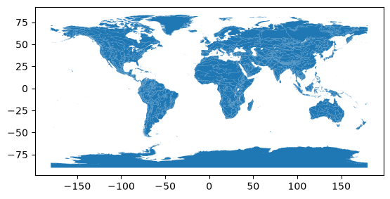

```python
### plot the ecoregions quickly
ecoreg_gdf.plot()
```

The ecoregions data comes from $Ecoregions2017^{©Resolve}$ depicting 846 ecoregions across the Earth (Google Earth Engine, n.d.). An ecoregion is an ecosystem of regional extent (Google Earth Engine, n.d.). Ecoregions2017 is, in fact, a revised version of the Terrestrial Ecoregions of the World (TEOW) map introduced in 2001 (Dinerstein et al., 2017; Kindt & Pedercini, 2025). This revised map was devised for the ultimate purpose of achieving the goal of protecting half the land on the Earth, as well as the associated biosphere (Nature Needs Half) (Dinerstein et al., 2017; Google Earth Engine, n.d.).

```python
gbif_gdf
```

| gbifID | month | year | geometry |
| --- | --- | --- | --- |
| 6579076304 | 8 | 2026 | POINT (-113.98101 65.29712) |
| 6579066804 | 8 | 2026 | POINT (-114.16184 65.36369) |
| 6567508500 | 8 | 2026 | POINT (-148.43443 70.18713) |
| 6566988348 | 7 | 2021 | POINT (-148.70137 63.50656) |
| 6566633015 | 8 | 2026 | POINT (-148.28656 70.28848) |
| ... | ... | ... | ... |
| 476814714 | 3 | 1950 | POINT (-151.72187 68.14837) |
| 476814397 | <NA> | 1951 | POINT (-77.7337 63.98512) |
| 476811514 | <NA> | 1915 | POINT (-51.12327 69.20275) |
| 476810918 | <NA> | 1915 | POINT (-51.12327 69.20275) |
| 177158602 | 10 | 1930 | POINT (-158.16667 62.46667) |

457 rows × 3 columns

The GBIF data was downloaded from gbif.org, and it shows the occurrence of barren-ground, including Porcupine, caribou. This data comes from 18 datasets, with the absolute majority of records being observations, primarily by people in the iNaturalist.org social network (iNaturalist, n.d.). A lesser share of the data comes from various collections.

The temporal range of our data is from 1895 to 2026, with most of the data collected in recent years. Given the limited number of observation, I decided to include the entirety of the available temporal range.

```python
# remove null values from gdf
gbif_gdf = gbif_gdf.dropna()

gbif_gdf
```

| gbifID | month | year | geometry |
| --- | --- | --- | --- |
| 6579076304 | 8 | 2026 | POINT (-113.98101 65.29712) |
| 6579066804 | 8 | 2026 | POINT (-114.16184 65.36369) |
| 6567508500 | 8 | 2026 | POINT (-148.43443 70.18713) |
| 6566988348 | 7 | 2021 | POINT (-148.70137 63.50656) |
| 6566633015 | 8 | 2026 | POINT (-148.28656 70.28848) |
| ... | ... | ... | ... |
| 476856243 | 4 | 1913 | POINT (-133.88821 56.94605) |
| 476844246 | 4 | 1925 | POINT (-164.34438 54.90612) |
| 476820300 | 3 | 1950 | POINT (-151.71088 68.15245) |
| 476814714 | 3 | 1950 | POINT (-151.72187 68.14837) |
| 177158602 | 10 | 1930 | POINT (-158.16667 62.46667) |

406 rows × 3 columns

#### Patterns of Migration During the Year

Below, we will try to find if the data can tell us anything about barren-ground caribou migraton patterns during the year.

```python
### join the gbif observations to the ecoregion polygons
gbif_ecoregion_df = (
    ecoreg_gdf

    ### match the CRS of the gbif data and the ecoregions
    .to_crs(gbif_gdf.crs)

    ### find ecoregion for each observation
    .sjoin(
        gbif_gdf,

        ### type of join
        how = 'inner',
        predicate = 'contains')

    ### subset columns
    [['OBJECTID', 'month']]

    ### expressively rename OBJECTID
    .rename(columns = {'OBJECTID' : 'ecoregion'})
)

gbif_ecoregion_df
```

|  | ecoregion | month |
| --- | --- | --- |
| 9 | 10.0 | 9 |
| 9 | 10.0 | 7 |
| 9 | 10.0 | 8 |
| 9 | 10.0 | 8 |
| 9 | 10.0 | 6 |
| ... | ... | ... |
| 831 | 837.0 | 7 |
| 831 | 837.0 | 6 |
| 831 | 837.0 | 8 |
| 831 | 837.0 | 8 |
| 831 | 837.0 | 7 |

374 rows × 2 columns

```python
### summarize the occurrences by ecoregion/month combination
occurrence_df = (
    gbif_ecoregion_df

    ### group by each ecoregion and month
    .groupby(['ecoregion', 'month'])

    ### and count the number of occurrences
    .agg(occurrences=('ecoregion', 'count'))
)

occurrence_df
```

| ecoregion | month | occurrences |
| --- | --- | --- |
| 10.0 | 2 | 2 |
|  | 3 | 1 |
|  | 5 | 4 |
|  | 6 | 24 |
|  | 7 | 31 |
| ... | ... | ... |
| 837.0 | 6 | 12 |
|  | 7 | 16 |
|  | 8 | 26 |
|  | 10 | 1 |
|  | 11 | 2 |

77 rows × 1 columns

```python
### get rid of rare observations (which are possibly misidentifications)
# occurrence_df = occurrence_df[occurrence_df.occurrences > 1]

# occurrence_df
```

While one would reasonably want to eliminate rare observations, considering that we have very limited data, I decided to include rare observation in the analysis.

```python
### calculate the mean # observations by ecoregion
mean_occurrences_by_ecoregion = (
    occurrence_df
    .groupby('ecoregion')
    .mean()
)

mean_occurrences_by_ecoregion.head()
```

| ecoregion | occurrences |
| --- | --- |
| 10.0 | 16.857143 |
| 11.0 | 1.000000 |
| 41.0 | 3.800000 |
| 43.0 | 5.500000 |
| 70.0 | 1.500000 |

```python
### calculate the mean # observations by month
mean_occurrences_by_month = (
    occurrence_df
    .groupby('month')
    .mean()
)

mean_occurrences_by_month.head()
```

| month | occurrences |
| --- | --- |
| 1 | 1.00 |
| 2 | 2.00 |
| 3 | 1.75 |
| 4 | 1.75 |
| 5 | 2.00 |

```python
### normalize by space and time for sampling effort
occurrence_df['norm_occurrences'] = (
    occurrence_df /
    mean_occurrences_by_ecoregion /
    mean_occurrences_by_month
)

### check it out
occurrence_df
```

| ecoregion | month | occurrences | norm_occurrences |
| --- | --- | --- | --- |
| 10.0 | 2 | 2 | 0.059322 |
|  | 3 | 1 | 0.033898 |
|  | 5 | 4 | 0.118644 |
|  | 6 | 24 | 0.277350 |
|  | 7 | 31 | 0.247953 |
| ... | ... | ... | ... |
| 837.0 | 6 | 12 | 0.314014 |
|  | 7 | 16 | 0.289787 |
|  | 8 | 26 | 0.406665 |
|  | 10 | 1 | 0.074627 |
|  | 11 | 2 | 0.179104 |

77 rows × 2 columns

Above, we normalized our observations to eliminate month and ecoregion as confounding factors in the frequency of recorded occurrences.

Below, we will do some basic visualizations to get a sense of the patterns of the pertinent attributes of the data.

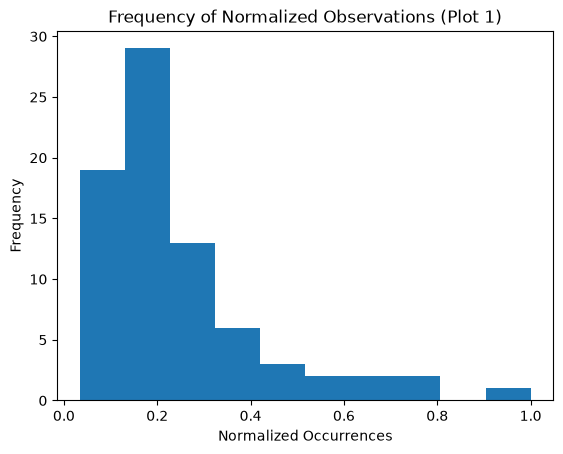

```python
### histogram plot
hist_plot = occurrence_df.norm_occurrences.plot(
    kind = 'hist',
    xlabel = 'Normalized Occurrences',
    title = 'Frequency of Normalized Observations (Plot 1)'
)
```

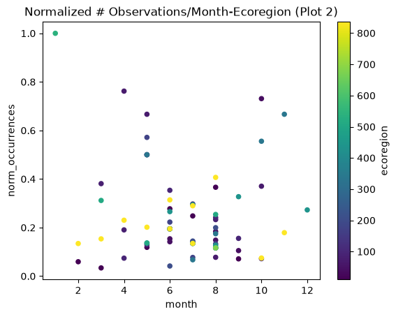

```python
### scatterplot of normalized observations/month/ecoregion
occurrence_df.reset_index().plot(

    ### type of plot
    kind = 'scatter',

    ### axes and color
    x = 'month',
    y = 'norm_occurrences',
    c = 'ecoregion',

    ### set title
    title = 'Normalized # Observations'
    '/Month-Ecoregion (Plot 2)'
)
```

In the plot above, it appears as if around the middle of the year, there are more ecoregion occurrences. However, to further ensure ourselves of this, we calculate the number of different ecoregion occurrences per month.

```python
### frequency of unique ecoregion observation / month
eco_freq_month = (occurrence_df

    ### get month from the multi-index
    .index.get_level_values('month')

    ### count frequnecy and sort by month
    .value_counts().sort_index()
)

eco_freq_month
```

```
month
1      1
2      2
3      4
4      4
5     10
6     15
7     12
8     17
9      4
10     5
11     2
12     1
Name: count, dtype: Int64
```

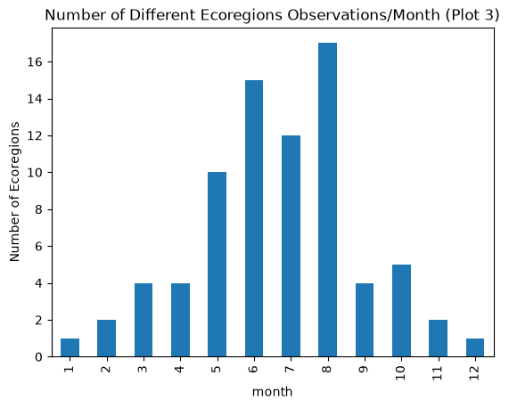

```python
### bar plot
eco_freq_month.plot(
        kind = 'bar',
        title = 'Number of Different Ecoregions '
        'Observations/Month (Plot 3)',
        ylabel = 'Number of Ecoregions'
    )
```

Our calculation and visualization show that, according to our data, barren-ground caribou has been observed more in late spring to early fall period. It is worth highlighting what this might say about our data. Barren-ground caribou inhabits northern North America, an area that is very remote and cold. Considering this, it is not unreasonable to assume that part of the reason for the limited number of observations of this subspecies may be attributed to the remoteness of the barren-ground caribou range and its extreme cold during and around winter.

We can see this obstacle in other studies in the area as well. For instance, regarding vegetation in caribou range, Rickbeil et al. (2018) discuss remoteness, in addition to “growth season length" and "cost”, causing difficulties in collecting in-situ data (p. 703).

```python
### simplify the geometry to speed up processing
ecoreg_gdf.geometry = ecoreg_gdf.simplify(

    0.05,
    preserve_topology = False
)

### change the CRS to Mercator for mapping
ecoreg_gdf = ecoreg_gdf.to_crs(ccrs.Mercator())

### check that the plot runs in a reasonable amount of time
ecoreg_gdf.hvplot(geo = True, crs = ccrs.Mercator())
```

```python
### prep the data, then combine the occurrence data with the ecoregions

### rename columns in ecoregID to match occurrence_df
ecoreg_gdf = ecoreg_gdf.rename(columns = {'OBJECTID': 'ecoregion'})

### make ecoreg ID the index for merge with occurrence_df
if ecoreg_gdf.index.name != 'ecoregion':
    ecoreg_gdf = ecoreg_gdf.set_index('ecoregion')

### join the occurrences with the plotting GeoDataFrame
occurrence_gdf = ecoreg_gdf.join(occurrence_df)

occurrence_gdf
```

| ecoregion | month | ECO_NAME | BIOME_NUM | BIOME_NAME | REALM | ECO_BIOME_ | NNH | ECO_ID | SHAPE_LENG | SHAPE_AREA | NNH_NAME | COLOR | COLOR_BIO | COLOR_NNH | LICENSE | geometry | occurrences | norm_occurrences |
| --- | --- | --- | --- | --- | --- | --- | --- | --- | --- | --- | --- | --- | --- | --- | --- | --- | --- | --- |
| 10.0 | 2 | Alaska-St. Elias Range tundra | 11.0 | Tundra | Nearctic | NE11 | 2 | 405 | 98.400727 | 28.388010 | Nature Could Reach Half Protected | #61D2F2 | #9ED7C2 | #7BC141 | CC-BY 4.0 | MULTIPOLYGON (((-16886356.561 9047887.14, -168... | 2 | 0.059322 |
|  | 3 | Alaska-St. Elias Range tundra | 11.0 | Tundra | Nearctic | NE11 | 2 | 405 | 98.400727 | 28.388010 | Nature Could Reach Half Protected | #61D2F2 | #9ED7C2 | #7BC141 | CC-BY 4.0 | MULTIPOLYGON (((-16886356.561 9047887.14, -168... | 1 | 0.033898 |
|  | 5 | Alaska-St. Elias Range tundra | 11.0 | Tundra | Nearctic | NE11 | 2 | 405 | 98.400727 | 28.388010 | Nature Could Reach Half Protected | #61D2F2 | #9ED7C2 | #7BC141 | CC-BY 4.0 | MULTIPOLYGON (((-16886356.561 9047887.14, -168... | 4 | 0.118644 |
|  | 6 | Alaska-St. Elias Range tundra | 11.0 | Tundra | Nearctic | NE11 | 2 | 405 | 98.400727 | 28.388010 | Nature Could Reach Half Protected | #61D2F2 | #9ED7C2 | #7BC141 | CC-BY 4.0 | MULTIPOLYGON (((-16886356.561 9047887.14, -168... | 24 | 0.277350 |
|  | 7 | Alaska-St. Elias Range tundra | 11.0 | Tundra | Nearctic | NE11 | 2 | 405 | 98.400727 | 28.388010 | Nature Could Reach Half Protected | #61D2F2 | #9ED7C2 | #7BC141 | CC-BY 4.0 | MULTIPOLYGON (((-16886356.561 9047887.14, -168... | 31 | 0.247953 |
| ... | ... | ... | ... | ... | ... | ... | ... | ... | ... | ... | ... | ... | ... | ... | ... | ... | ... | ... |
| 837.0 | 6 | Kalaallit Nunaat Arctic steppe | 11.0 | Tundra | Nearctic | NE11 | 2 | 417 | 902.266734 | 78.035823 | Nature Could Reach Half Protected | #64DEE3 | #9ED7C2 | #7BC141 | CC-BY 4.0 | MULTIPOLYGON (((-1982415.951 13023377.561, -20... | 12 | 0.314014 |
|  | 7 | Kalaallit Nunaat Arctic steppe | 11.0 | Tundra | Nearctic | NE11 | 2 | 417 | 902.266734 | 78.035823 | Nature Could Reach Half Protected | #64DEE3 | #9ED7C2 | #7BC141 | CC-BY 4.0 | MULTIPOLYGON (((-1982415.951 13023377.561, -20... | 16 | 0.289787 |
|  | 8 | Kalaallit Nunaat Arctic steppe | 11.0 | Tundra | Nearctic | NE11 | 2 | 417 | 902.266734 | 78.035823 | Nature Could Reach Half Protected | #64DEE3 | #9ED7C2 | #7BC141 | CC-BY 4.0 | MULTIPOLYGON (((-1982415.951 13023377.561, -20... | 26 | 0.406665 |
|  | 10 | Kalaallit Nunaat Arctic steppe | 11.0 | Tundra | Nearctic | NE11 | 2 | 417 | 902.266734 | 78.035823 | Nature Could Reach Half Protected | #64DEE3 | #9ED7C2 | #7BC141 | CC-BY 4.0 | MULTIPOLYGON (((-1982415.951 13023377.561, -20... | 1 | 0.074627 |
|  | 11 | Kalaallit Nunaat Arctic steppe | 11.0 | Tundra | Nearctic | NE11 | 2 | 417 | 902.266734 | 78.035823 | Nature Could Reach Half Protected | #64DEE3 | #9ED7C2 | #7BC141 | CC-BY 4.0 | MULTIPOLYGON (((-1982415.951 13023377.561, -20... | 2 | 0.179104 |

77 rows × 17 columns

```python
### activate panel and hvplot extensions you'll need for the interactive plot
pn.extension()
hv.extension('bokeh')
```

```python
### plot the data

### get the plot bounds so they don't change with the slider
xmin, ymin, xmax, ymax = occurrence_gdf.total_bounds

### define the slider widget
slider = pn.widgets.DiscreteSlider(
    name = 'month',
    options = {calendar.month_name[i]: i for i in range(1, 13)}
)

### make the basemap tile object
carto_tiles = hv.Tiles(
    ('https://basemaps.cartocdn.com/rastertiles/voyager/{Z}/{X}/{Y}.png?'
    'key=cb1_446c_1_8946b413de0ace50f732dbf1'),
    name = 'CARTO'
)

### create a plot parameters dictionary
plot_layout_dic = {

        ### set dimensions of map
        'frame_height' : 600,
        'frame_width' : 900,

        ### put the widget at the bottom of the map
        'widget_location' : 'bottom',

        ### set plot boundaries
        'xlim' : (xmin, xmax),
        'ylim' : (ymin, ymax),

        ## show what colors mean
        'colorbar' : True,
        'clabel' : 'Normalized Occurrences',

        ### creat geographic plot
        'geo' : True,

        ### set coordinate ref. sys.
        'crs' : ccrs.Mercator(),

        ### set bg tiles
        'tiles' : carto_tiles

}

### plot occurrence by ecoregion and month
migration_plot = (occurrence_gdf
        .hvplot(

        ### color by norm. # of occurrence
        c = 'norm_occurrences',

        ### include ecoregion name in pop-up
        hover_cols = 'ECO_NAME',

        ### group by month
        groupby = 'month',


        ### add a title
        title = 'Barren-Ground Caribou Migration '
        'During the Year (Map 1)',

        ### parameters dictionary
        **plot_layout_dic,

        ### set the widgets
        widgets = {'month': slider}
    )
)

### wrap  plot in the Panel layout
interactive_migration_plot = pn.panel(migration_plot)

### check it out
interactive_migration_plot
```

```
BokehModel(combine_events=True, render_bundle={'docs_json': {'7eb249a2-bb08-45a8-93d5-b95239d93da5': {'version…
```

[figure not shown]

In the map above, we see that in June, July, and August, some places that are impossibly far (e.g. Antarctica) are lit up, implying the occurrence of barren-ground caribou there. However, given that it is physically impossible for the caribou to migrate to those locations, let's figure out what the problem may be.

To this end, I plot all the observation data points against the ecoregions.

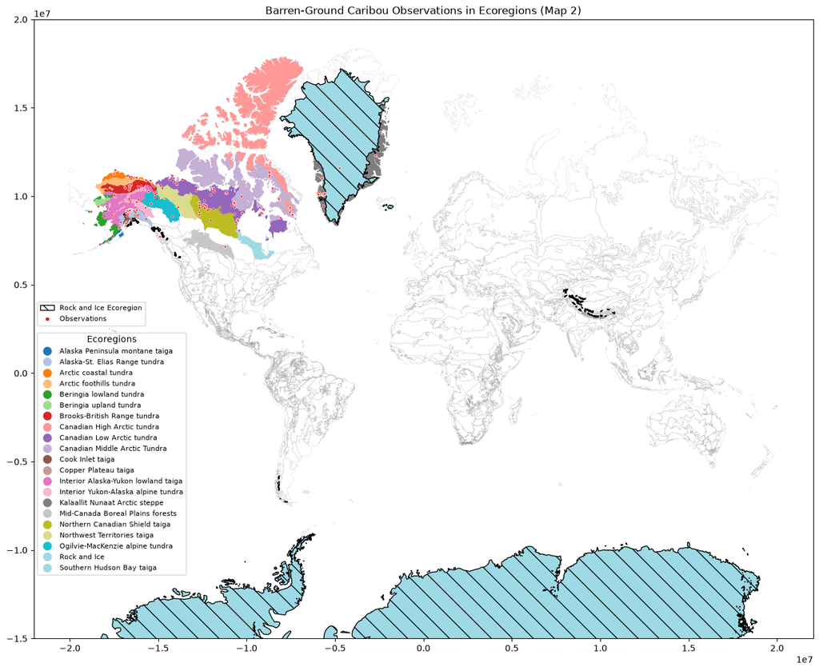

```python
### plot occurrences against ecoregions

fig, ax = plt.subplots(figsize = (16, 32))

### plot an outline of all ecoregions
ecoreg_gdf.plot(
    ax = ax,
    color = 'none',
    linewidth = 0.5,
    alpha = 0.1
)

### plot ecoregions with occurrences
occurrence_gdf.plot(
    ax = ax,
    column = 'ECO_NAME',
    cmap = 'tab20',
    legend = True,
    legend_kwds={
        'loc': 'upper left',
        'fontsize': 8,
        'title': 'Ecoregions',
        'bbox_to_anchor': (0, 0.5)
    }
)

### highlight the Rock & Ice ecoregion
ecoreg_gdf[ecoreg_gdf.ECO_NAME ==
               'Rock and Ice'].plot(
                   ax = ax,
                   color = 'none',
                   hatch = '\\'
               )

### plot occurrences
gbif_gdf.to_crs(ecoreg_gdf.crs).plot(
    ax = ax,
    facecolor = 'red',
    edgecolor = 'white',
    markersize = 6,
    linewidth = 0.5
)

### prevent distortion by Antarctica
ax.set_ylim(-15000000, 20000000)

### set title
ax.set_title('Barren-Ground Caribou '
    'Observations in Ecoregions (Map 2)')

### store occurrence ecoregion legend
eco_legend = ax.get_legend()

### legend elements for ecoregion-highlight and observation
legend_elements = [
    Patch.Patch(
        facecolor = 'none',
        edgecolor = 'black',
        hatch = '\\\\',
        label = 'Rock and Ice Ecoregion'
    ),
    Line2D.Line2D(
        [0], [0],
        marker = 'o',
        color = 'w',
        markerfacecolor = 'red',
        markeredgecolor = 'white',
        markersize = 5,
        label = 'Observations'
    )
]

### set the legend with the new elements
ax.legend(
    handles = legend_elements,
    loc = 'lower left',
    bbox_to_anchor = (0, 0.5),
    fontsize = 8
)

### re-add original legend
ax.add_artist(eco_legend)

plt.show()
```

Map 2 shows that the Rock and Ice ecoregion is not one contiguous area but rather multiple areas around the world. This can be explained by the fact that some ecoregions in the Ecoregions2017 map are split with part of their attributes, such as ECO_ID, remaining the same (Google Earth Engine, n.d.). So, while there are some caribou observations in the Rock and Ice ecoregion of North America and Greenland (perhaps along their migration route or because of some strays), our map highlights all of Rock and Ice ecoregions around the world.

I decided to remove all the observations in the Rock and Ice ecoregion. Although this omission does introduce a bit of a limitation to our analysis, it enhances our ability to better view the migration patterns of the caribou.

```python
### check out all observations in Rock & Ice ecoregion
occurrence_gdf[occurrence_gdf.ECO_NAME == 'Rock and Ice']
```

| ecoregion | month | ECO_NAME | BIOME_NUM | BIOME_NAME | REALM | ECO_BIOME_ | NNH | ECO_ID | SHAPE_LENG | SHAPE_AREA | NNH_NAME | COLOR | COLOR_BIO | COLOR_NNH | LICENSE | geometry | occurrences | norm_occurrences |
| --- | --- | --- | --- | --- | --- | --- | --- | --- | --- | --- | --- | --- | --- | --- | --- | --- | --- | --- |
| 207.0 | 6 | Rock and Ice | 11.0 | N/A | N/A | N/A | 0 | 0 | 6629.94446 | 6487.848621 | N/A | #E2E2E0 | #FFEAAF | #E2E2E0 | CC-BY 4.0 | MULTIPOLYGON (((-20037319.088 -19606422.663, -... | 1 | 0.041744 |
|  | 7 | Rock and Ice | 11.0 | N/A | N/A | N/A | 0 | 0 | 6629.94446 | 6487.848621 | N/A | #E2E2E0 | #FFEAAF | #E2E2E0 | CC-BY 4.0 | MULTIPOLYGON (((-20037319.088 -19606422.663, -... | 5 | 0.144462 |
|  | 8 | Rock and Ice | 11.0 | N/A | N/A | N/A | 0 | 0 | 6629.94446 | 6487.848621 | N/A | #E2E2E0 | #FFEAAF | #E2E2E0 | CC-BY 4.0 | MULTIPOLYGON (((-20037319.088 -19606422.663, -... | 8 | 0.199609 |

```python
### remove all observations in Rock & Ice ecoregion
occurrence_gdf = (occurrence_gdf[occurrence_gdf.ECO_NAME
    != 'Rock and Ice'])
```

```python
### get the new plot bounds
xmin, ymin, xmax, ymax = occurrence_gdf.total_bounds

### update plot boundaries
plot_layout_dic['xlim'] = (xmin, xmax)
plot_layout_dic['ylim'] = (ymin, ymax)

### plot occurrence by ecoregion and month
correct_migration_plot = (occurrence_gdf
        .hvplot(

        ### color by norm. # of occurrence
        c = 'norm_occurrences',

        ### include ecoregion name in pop-up
        hover_cols = 'ECO_NAME',

        ### group by month
        groupby = 'month',

        ### add a title
        title = 'Barren-Ground Caribou '
        'Migration During the Year (Map 3)',

        ### parameters dictionary
        **plot_layout_dic,

        ### set the widgets
        widgets = {'month': slider}
    )
)



### wrap  plot in the Panel layout
interactive_correct_plot = pn.panel(correct_migration_plot)

### check it out
interactive_correct_plot
```

```
BokehModel(combine_events=True, render_bundle={'docs_json': {'500c9d82-41a5-4309-9d14-d55aebee0954': {'version…
```

[figure not shown]

It is worth reiterating that, as mentioned before, we expect limited observation in the colder months of the year -- both because of remoteness and coldness of barren-ground caribou range. However, another reason for the small number of occurrence ecoregions would be caribous' movement minimization to preserve energy during the winter, as mentioned above (Joly et al., 2018).

Despite the limitations of our data, we can still see the pattern of movement northwards in the spring, dispersion in the Arctic and tundra zones in the summer, and hints of southward return towards inland in the fall (for more detail, see COSEWIC, 2016).

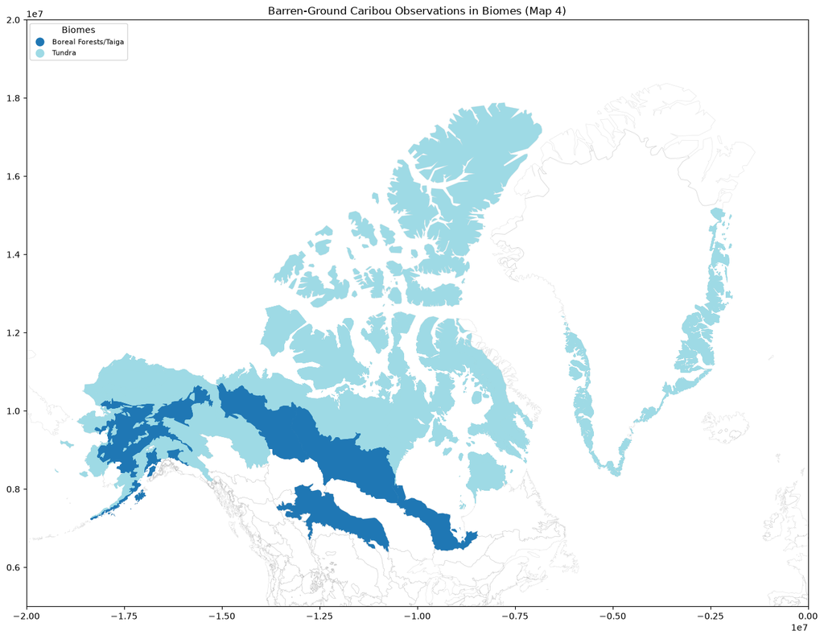

```python
### plot biomes where caribou observation has happened

fig, ax = plt.subplots(figsize = (16, 32))

### outline of all biomes
ecoreg_gdf.plot(
    ax = ax,
    column = 'BIOME_NAME',
    color = 'none',
    linewidth = 0.5,
    alpha = 0.1
)

### highlight occurrence biomes
occurrence_gdf.plot(
    ax = ax,
    column = 'BIOME_NAME',
    cmap = 'tab20',
    legend = True,
    legend_kwds={
        'loc': 'upper left',
        'fontsize': 8,
        'title': 'Biomes',
        'bbox_to_anchor': (0, 1)
    }
)

### limit map extent to what is relevant
ax.set_ylim(5000000, 20000000)
ax.set_xlim(-20000000, 0)

### set title
ax.set_title('Barren-Ground Caribou '
    'Observations in Biomes (Map 4)')

plt.show()
```

Map 4 shows the biomes of all the occurrences. A biome is geographic region defined "by its vegetation, soil, climate, and wildlife" (National Geographic Society, 2026, para. 1). Our data visualization aligns with boreal forest and tundra being part of the habitat of barren-ground caribou, as mentioned above.

#### Habitat Range Across Time

Below, we will examine if our data can tell us anything about changes in barren-ground caribou range over the years.

```python
### join the gbif observations to the ecoregion polygons
yr_occurrence_df = (
    ecoreg_gdf

    ### match the CRS of the gbif data and the ecoregions
    .to_crs(gbif_gdf.crs)

    ### find ecoregion for each observation
    .sjoin(
        gbif_gdf,

        ### type of join
        how = 'inner',
        predicate = 'contains')

    ### subset columns
    [['year']]
)

yr_occurrence_df.head()
```

| ecoregion | year |
| --- | --- |
| 10.0 | 2018 |
| 10.0 | 2025 |
| 10.0 | 2005 |
| 10.0 | 2018 |
| 10.0 | 2015 |

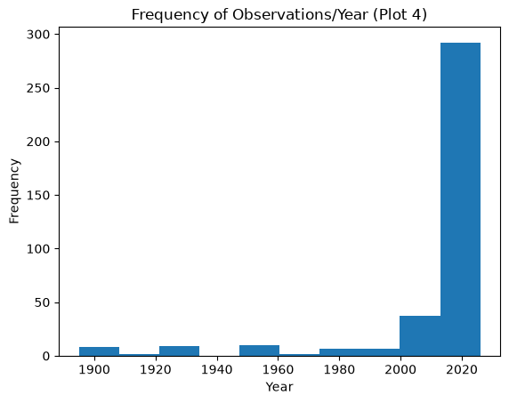

```python
### scatterplot
yr_occurrence_df.plot(
    kind = 'hist',
    xlabel = 'Year',
    title = 'Frequency of Observations/Year (Plot 4)',
    legend = False
)
```

Plot 4 demonstrates that the majority of our observations occurred over the last decade.

```python
### join the occurrences with the plotting GeoDataFrame
gbif_ecoregion_yr_gdf = ecoreg_gdf.join(
    yr_occurrence_df,
    how = 'inner')

gbif_ecoregion_yr_gdf
```

| ecoregion | ECO_NAME | BIOME_NUM | BIOME_NAME | REALM | ECO_BIOME_ | NNH | ECO_ID | SHAPE_LENG | SHAPE_AREA | NNH_NAME | COLOR | COLOR_BIO | COLOR_NNH | LICENSE | geometry | year |
| --- | --- | --- | --- | --- | --- | --- | --- | --- | --- | --- | --- | --- | --- | --- | --- | --- |
| 10.0 | Alaska-St. Elias Range tundra | 11.0 | Tundra | Nearctic | NE11 | 2 | 405 | 98.400727 | 28.388010 | Nature Could Reach Half Protected | #61D2F2 | #9ED7C2 | #7BC141 | CC-BY 4.0 | MULTIPOLYGON (((-16886356.561 9047887.14, -168... | 2018 |
| 10.0 | Alaska-St. Elias Range tundra | 11.0 | Tundra | Nearctic | NE11 | 2 | 405 | 98.400727 | 28.388010 | Nature Could Reach Half Protected | #61D2F2 | #9ED7C2 | #7BC141 | CC-BY 4.0 | MULTIPOLYGON (((-16886356.561 9047887.14, -168... | 2025 |
| 10.0 | Alaska-St. Elias Range tundra | 11.0 | Tundra | Nearctic | NE11 | 2 | 405 | 98.400727 | 28.388010 | Nature Could Reach Half Protected | #61D2F2 | #9ED7C2 | #7BC141 | CC-BY 4.0 | MULTIPOLYGON (((-16886356.561 9047887.14, -168... | 2005 |
| 10.0 | Alaska-St. Elias Range tundra | 11.0 | Tundra | Nearctic | NE11 | 2 | 405 | 98.400727 | 28.388010 | Nature Could Reach Half Protected | #61D2F2 | #9ED7C2 | #7BC141 | CC-BY 4.0 | MULTIPOLYGON (((-16886356.561 9047887.14, -168... | 2018 |
| 10.0 | Alaska-St. Elias Range tundra | 11.0 | Tundra | Nearctic | NE11 | 2 | 405 | 98.400727 | 28.388010 | Nature Could Reach Half Protected | #61D2F2 | #9ED7C2 | #7BC141 | CC-BY 4.0 | MULTIPOLYGON (((-16886356.561 9047887.14, -168... | 2015 |
| ... | ... | ... | ... | ... | ... | ... | ... | ... | ... | ... | ... | ... | ... | ... | ... | ... |
| 837.0 | Kalaallit Nunaat Arctic steppe | 11.0 | Tundra | Nearctic | NE11 | 2 | 417 | 902.266734 | 78.035823 | Nature Could Reach Half Protected | #64DEE3 | #9ED7C2 | #7BC141 | CC-BY 4.0 | MULTIPOLYGON (((-1982415.951 13023377.561, -20... | 2024 |
| 837.0 | Kalaallit Nunaat Arctic steppe | 11.0 | Tundra | Nearctic | NE11 | 2 | 417 | 902.266734 | 78.035823 | Nature Could Reach Half Protected | #64DEE3 | #9ED7C2 | #7BC141 | CC-BY 4.0 | MULTIPOLYGON (((-1982415.951 13023377.561, -20... | 1979 |
| 837.0 | Kalaallit Nunaat Arctic steppe | 11.0 | Tundra | Nearctic | NE11 | 2 | 417 | 902.266734 | 78.035823 | Nature Could Reach Half Protected | #64DEE3 | #9ED7C2 | #7BC141 | CC-BY 4.0 | MULTIPOLYGON (((-1982415.951 13023377.561, -20... | 2026 |
| 837.0 | Kalaallit Nunaat Arctic steppe | 11.0 | Tundra | Nearctic | NE11 | 2 | 417 | 902.266734 | 78.035823 | Nature Could Reach Half Protected | #64DEE3 | #9ED7C2 | #7BC141 | CC-BY 4.0 | MULTIPOLYGON (((-1982415.951 13023377.561, -20... | 2024 |
| 837.0 | Kalaallit Nunaat Arctic steppe | 11.0 | Tundra | Nearctic | NE11 | 2 | 417 | 902.266734 | 78.035823 | Nature Could Reach Half Protected | #64DEE3 | #9ED7C2 | #7BC141 | CC-BY 4.0 | MULTIPOLYGON (((-1982415.951 13023377.561, -20... | 2012 |

374 rows × 16 columns

```python
### remove occurrences in Rock & Ice ecosystem
gbif_ecoregion_yr_gdf = gbif_ecoregion_yr_gdf[
    gbif_ecoregion_yr_gdf.ECO_NAME != 'Rock and Ice']
```

Since about three-fourths of all our observations happened in the last decade, we limit our analysis to the years since 2017.

```python
### set the starting year
begin = (gbif_ecoregion_yr_gdf.year >= 2017)

print('total # observations in dataset:', len(gbif_ecoregion_yr_gdf))
print('total # observations since 2017:', len(gbif_ecoregion_yr_gdf[begin]))
```

```
total # observations in dataset: 360
total # observations since 2017: 269
```

```python
### plot occurrence by ecoregion and month
yearly_range_plot = (
    gbif_ecoregion_yr_gdf[begin]
        .hvplot(

        ### color by ecoregion
        c = 'ECO_NAME',

        ### group by month
        groupby = 'year',

        ### add a title
        title = 'Barren-Ground Caribou Ecoregion '
        'Range Per Year (Map 5)',

        ### parameters dictionary
        **plot_layout_dic,

    )
)

### wrap  plot in the Panel layout
interactive_yearly_plot = pn.panel(yearly_range_plot)

### check it out
interactive_yearly_plot
```

```
BokehModel(combine_events=True, render_bundle={'docs_json': {'1f45c1f3-fbeb-41b9-9c18-c628fef9bf60': {'version…
```

[figure not shown]

Looking at the ecoregion range of caribou occurrence over the last decade, something that pops out is their recent observations in Canadian Middle Arctic and High Arctic Tundra. This apparent northwards expansion of caribou range aligns with the longer periods of warmer weather, due to climate change, driving barren-ground caribou further north for cooler and windier areas and away from the escalating harrassment of insects, as mentioned above.

#### Saving Maps

*Below, we save our over-the-year migration and over-time range change interactive maps*

```python
### make paths for maps to live
incorrect_migration_path = os.path.join(data_dir,
    'incorrect_migration_plot.html')

migration_map_path = os.path.join(data_dir,
    'bg_caribou_migration_plot.html')

range_map_path = os.path.join(data_dir,
    'bg_caribou_range_plot.html')

plots_paths = [
    (interactive_migration_plot, incorrect_migration_path),
    (interactive_correct_plot, migration_map_path),
    (interactive_yearly_plot, range_map_path)
    ]

### export the maps as .html files
for plot, path in plots_paths:
    plot.save(
        path,
        embed = True,
        resources = 'inline',
    )
```

#### Reflection

One of the most interesting outcomes of this analysis was the emerging insights about our data and their limitations (e.g. our observation data suffered from an extreme dearth). Additionally, these limitations forced us to make choices during the processing of the data that compromised the range and quality of what we could deduce even further (e.g. due to the nature of ecoregion classification in Ecoregions2017, we excluded observations in the Rock and Ice ecoregions of North America and Greenland) -- as if limitation begot limitation. Considering this, it is important to highlight that our conclusions are not strong enough to stand alone. At best, they can be helpful in providing insights for future research directions or in mirroring the findings of other studies.

### References

Association on American Indian Affairs. (2002). *The Gwich’in: Caribou People*. https://www.indian-affairs.org/blog/the-gwichin-caribou-people

Berkeland, M. (n.d.). *Caribou food for thought: The future of forage in the Arctic*. U.S. Fish & Wildlife Service. https://www.fws.gov/story/caribou-food-thought

Boulanger, J., Kite, R., Campbell, M., Shaw, J., Lee, D., & Atkinson, S. (2024). Estimating the effects of roads on migration: A barren-ground caribou case study. *Canadian Journal of Zoology, 102*(5), 476–493. https://doi.org/10.1139/cjz-2023-0121

Committee on the Status of Endangered Wildlife in Canada (COSEWIC). (2016). *COSEWIC assessment and status report on the caribou (Rangifer tarandus), barren-ground population, in Canada. Environment and Climate Change Canada*. https://publications.gc.ca/collections/collection_2017/eccc/CW69-14-746-2017-eng.pdf

Dinerstein, E., Olson, D., Joshi, A., Vynne, C., Burgess, N. D., Wikramanayake, E., Hahn, N., Palminteri, S., Hedao, P., Noss, R., Hansen, M., Locke, H., Ellis, E. C., Jones, B., Barber, C. V., Hayes, R., Kormos, C., Martin, V., Crist, E., ... Saleem, M. (2017). An ecoregion-based approach to protecting half the terrestrial realm. *BioScience, 67*(6), 534–545. https://doi.org/10.1093/biosci/bix014

Google Earth Engine. (n.d.). *RESOLVE ecoregions 2017*. Google for Developers. https://developers.google.com/earth-engine/datasets/catalog/RESOLVE_ECOREGIONS_2017

iNaturalist. (n.d.). *iNaturalist research-grade observations* [Data set]. Global Biodiversity Information Facility (GBIF). https://www.gbif.org/dataset/50c9509d-22c7-4a22-a47d-8c48425ef4a7

Joly, K., Gurarie, E., Sorum, M. S., Kaczensky, P., Cameron, M. D., Jakes, A. F., Borg, B. L., Nandintsetseg, D., Hopcraft, J. G. C., Buuveibaatar, B., Jones, P. F., Mueller, T., Walzer, C., Olson, K. A., Payne, J. C., Yadamsuren, A., & Hebblewhite, M. (2019). Longest terrestrial migrations and movements around the world. *Scientific Reports, 9*, Article 15333. https://doi.org/10.1038/s41598-019-51884-5

Joly, K., Rasic, J., Mason, R., & Lukin, M. (2018, June 12). History, purpose, and status of caribou movements in Northwest Alaska. *Alaska Park Science, 17*(1). https://www.nps.gov/articles/aps-17-1-7.htm

Kindt, R., & Pedercini, F. (2025). EcoregionsTreeFinder—A global dataset documenting the abundance of observations of over 45,000 tree species in 828 terrestrial ecoregions. *Global Ecology and Biogeography, 34*(6), Article e70064. https://doi.org/10.1111/geb.70064

National Geographic Society. (2026, September 15). *The five major types of biomes*. https://education.nationalgeographic.org/resource/five-major-types-biomes/

National Park Service. (2026, January 20). *Caribou vs. reindeer*. U.S. Department of the Interior. https://www.nps.gov/articles/000/reinderrvscaribou.htm

Rigell, E. (n.d.). Largest on Earth: *Caribou migration*. Earth.com. https://www.earth.com/earthpedia-articles/largest-on-earth-caribou-migration/

Rickbeil, G. J. M., Hermosilla, T., Coops, N. C., White, J. C., Wulder, M. A., & Lantz, T. C. (2018). Changing northern vegetation conditions are influencing barren ground caribou (Rangifer tarandus groenlandicus) post-calving movement rates. *Journal of Biogeography, 45*(3), 702–713. https://doi.org/10.1111/jbi.13161